# R Mini-Project Report

Mike Nsubuga

6/4/2021

## MSB7102 Mini-project, Semester 1, 2021

### Student Details

##### Name: Mike Nsubuga

##### Student Number: 2000720912

##### Registration Number: 2020/HD07/20912U

##### Course: R and Bio Conductor

##### Email: nsubugamike021@gmail.com

### Background

This is an assessed exercise that will contribute to coursework for this module. It is aimed at providing an experience with all that has been covered throughout the semester. The tasks are based on two Bioconductor packages; phyloseq and DEseq2. Endeavor to look at the documentation and the links indicated below may be useful. The data files are located in the shared google drive folder.

### Data sources and description

The data used in this exercise is derived and was generated by Kolistic et al in their study “The dynamics of the human infant gut microbiome in development and progression toward Type 1 Diabetes”. See full publication at https://doi.org/10.1016/j.chom.2015.01.001. Briefly, this was a prospective analysis of developing gut microbiome in infants en route to type 1 diabetes. Infants from Finland and Estonia were recruited at birth based on predisposition to autoimmunity determined by human leukocyte antigen (HLA) genotyping. The cohort consists of 33 infants, 11 of which seroconverted to serum autoantibody positivity and of those, four developed T1D within the three-year time-frame of this study.

### Question 1

#### 1.1.1. Descriptive summaries of the subject data using appropriate graphics and statistical summary measures.

Using the summary function to get a summary of descriptive statistics which include mean, median, 25th and 75th quartiles, min, max

```r
data <- read.csv("diabimmune_16s_t1d_metadata.csv");
summary(data)
```

```
##   Sample_ID          Subject_ID        Case_Control          Gender
##  Length:777         Length:777         Length:777         Length:777
##  Class :character   Class :character   Class :character   Class :character
##  Mode  :character   Mode  :character   Mode  :character   Mode  :character
##
##
##
##  Delivery_Route     Age_at_Collection
##  Length:777         Min.   :   6.0
##  Class :character   1st Qu.: 229.0
##  Mode  :character   Median : 452.0
##                     Mean   : 482.9
##                     3rd Qu.: 702.0
##                     Max.   :1233.0
```

```r
dim(data)
```

```
## [1] 777   6
```

```r
class(data)
```

```
## [1] "data.frame"
```

#### 1.1.2. Graphical summary representation of the data.

Bar charts representing the number of occurences in each category

#### 1.1.3 Number of Cases and Controls against the Genders.

```r
library(ggplot2)
table(data$Case_Control)
```

```
##
##    case control
##     260     517
```

```r
table(data$Gender)
```

```
##
## female   male
##    412    365
```

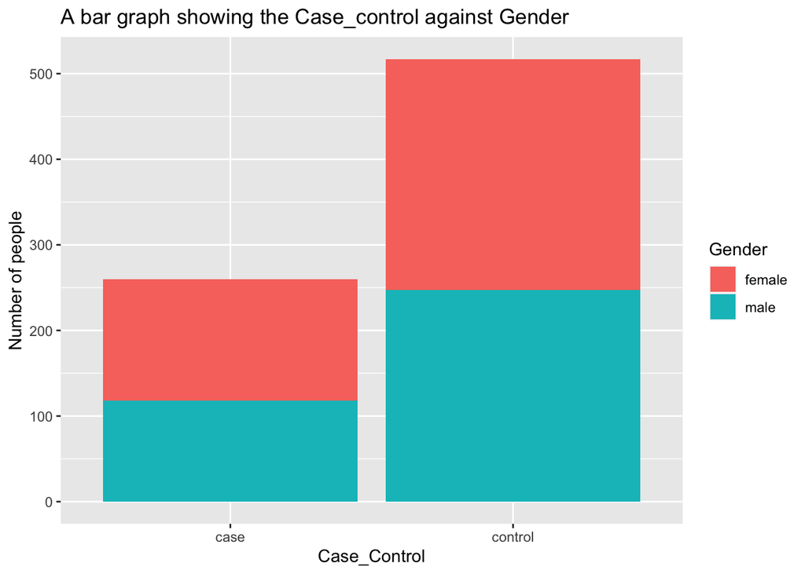

```r
qplot(data$Case_Control, fill = data$Gender) + geom_bar() + labs(title = "A bar graph showing the Case_control against Gender", x = "Case_Control", y= "Number of people", fill = "Gender")
```

#### 1.1.4 The Delivery Route against the Gender

```r
library(ggplot2)
table(data$Case_Control)
```

```
##
##    case control
##     260     517
```

```r
table(data$Gender)
```

```
##
## female   male
##    412    365
```

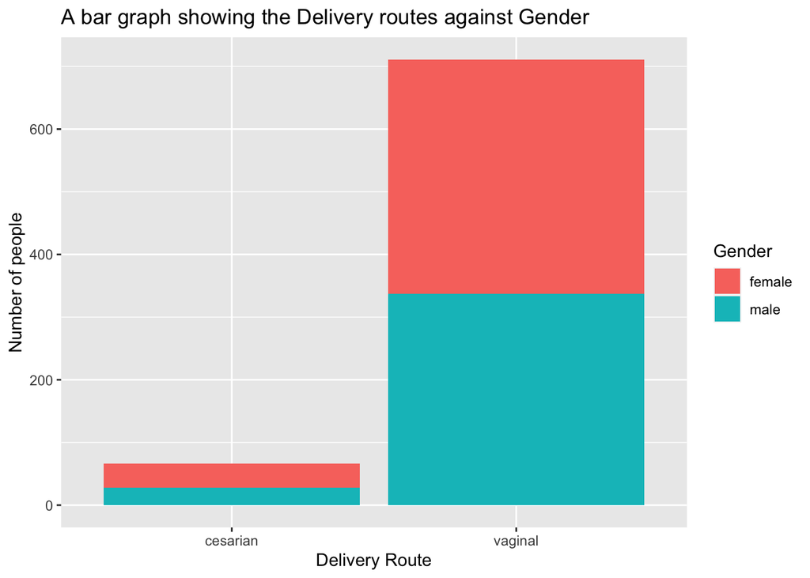

```r
qplot(data$Delivery_Route, fill = data$Gender) + geom_bar() + labs(title = "A bar graph showing the Delivery routes against Gender", x = "Delivery Route", y= "Number of people", fill = "Gender")
```

#### 1.2.1. Appropriate tests to check for association/independency between disease status and other variables.

Two random variables x and y are called independent if the probability distribution of one variable is not affected by the presence of another.

Chi-square test examines whether rows and columns of a contigency table are statistically significatly associated

- Null hypothesis(H0): the row and the column variables of the contigency table are independent
- Alternate hypothesis(H1): row and column variables are dependent

##### Test the hypothesis whether the disease status is independent of their Delivery Mode at .05 significance level

```r
tbDelivery <- table(data$Case_Control, data$Delivery_Route)  #Generate a contigency table of Disease status and Delivery Mode
chisq.test(tbDelivery)
```

```
##
##  Pearson's Chi-squared test with Yates' continuity correction
##
## data:  tbDelivery
## X-squared = 34.649, df = 1, p-value = 3.949e-09
```

As the p-value 3.949e-09 is less than the .05 significance level, we reject the null hypothesis that the Disease Control status is independent of the Delivery Mode. This means that the two variables are somewhat related

##### Test the hypothesis whether the disease status is independent of their Gender at .05 significance level.

```r
tbGender <- table(data$Case_Control, data$Gender)  #Generate a contigency table of Disease status and Gender
chisq.test(tbGender)
```

```
##
##  Pearson's Chi-squared test with Yates' continuity correction
##
## data:  tbGender
## X-squared = 0.30687, df = 1, p-value = 0.5796
```

As the p-value 0.5796 is greater than the .05 significance level, we do not reject the null hypothesis that the Disease Control status is independent of the Gender. It indicates strong evidence for the null hypothesis and reject the alternative hypothesis. This means that there’s no relationship between the two variables being studied

##### Test the hypothesis whether the disease status is independent of their Age_at_Collection at .05 significance level.

```r
tbAge <- table(data$Case_Control, data$Age_at_Collection)  #Generate a contigency table of Disease status and Age
chisq.test(tbAge)
```

```
##
##  Pearson's Chi-squared test
##
## data:  tbAge
## X-squared = 532.07, df = 542, p-value = 0.6115
```

#### 1.2.2. Mosaic Plots.

To further visualise the tests of association/independecy, they can be plotted on a mosaic plot, which can give us insights on how the two variables are related. Units are in standard deviations, so a residual greater than 2 or less than -2 represents a significant departure from independence. A mosaic plot maps standardised residuals to cells, positive sign is for blue and negative sign is for red ones. Blue means there are more observations in the cell than would be expected under the null model(independence). Red means there are fewer observations than would have been expected

##### A mosaic plot for Case Control vs Delivery Route

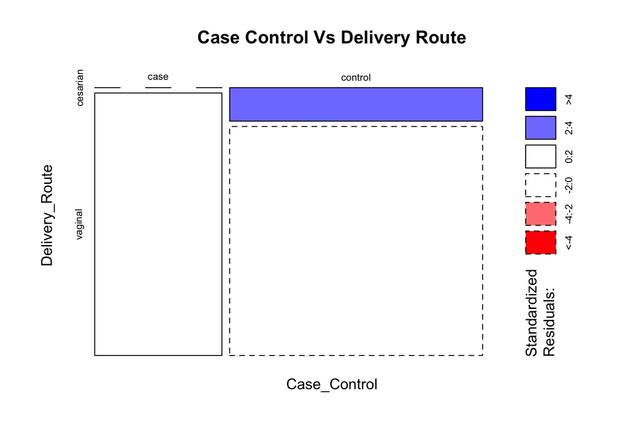

```r
library(graphics)
mosaicplot(~ Case_Control + Delivery_Route, data = data, main = "Case Control Vs Delivery Route", shade = TRUE)
```

##### A mosaic plot for Case Control vs Gender

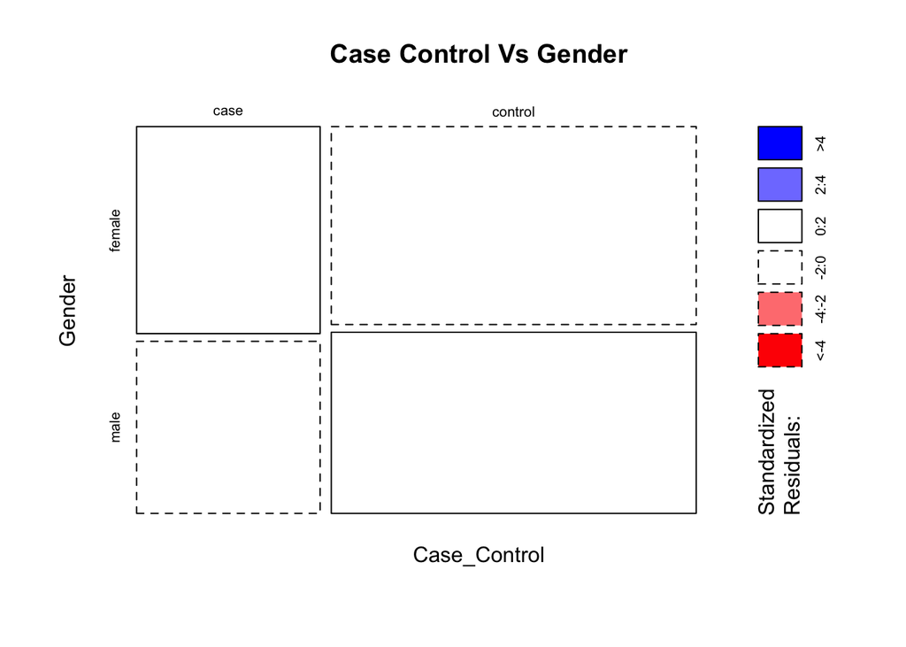

```r
mosaicplot(~ Case_Control + Gender, data = data, main = "Case Control Vs Gender", shade = TRUE)
```

The plot indicates no significant relationship when you look at the standardised residuals

##### A mosaic plot for Case Control vs Age at Collection

[figure not shown]

```r
mosaicplot(~ Case_Control + Age_at_Collection, data = data, main = "Case Control Vs Age", shade = TRUE)
```

### Question 2

### Phyloseq

Using phyloseq, create a phyloseq object. this will comprise the OTU abundance, taxonomy(provided in the .txt file) and sample data(provided in the .csv file)

```r
otuTable <- read.table("otu_table")  #Importing the OTU table
#head(otuTable, n = 1)
```

```r
taxaTable <- read.table("taxa_table") #Importing the Taxa table
#head(taxaTable, n = 1)
```

```r
dim(otuTable)
```

```
## [1] 2240  777
```

```r
dim(taxaTable)
```

```
## [1] 2240    7
```

```r
class(otuTable)
```

```
## [1] "data.frame"
```

```r
class(taxaTable)
```

```
## [1] "data.frame"
```

```r
#Converting the Taxa and OTU Table into a Matrix
mtaxaTable <- as.matrix(taxaTable)
motuTable <- as.matrix(otuTable)

class(mtaxaTable)
```

```
## [1] "matrix" "array"
```

```r
class(motuTable)
```

```
## [1] "matrix" "array"
```

```r
#Data Cleansing. This is done to have consistent data across all the matrices
#This will involve making sure that the OTU/taxa row names match. Currently they dont as taxa have a trailing ";"

#rownames(mtaxaTable)[rownames(mtaxaTable) == "4333897;"] = "4333897"

head(mtaxaTable, n=1)
```

```
##          Domain.        Phylum.              Class.
## 4333897; "k__Bacteria;" "p__Proteobacteria;" "c__Gammaproteobacteria;"
##          Order.                  Family.                  Genus. Species
## 4333897; "o__Enterobacteriales;" "f__Enterobacteriaceae;" "g__;" "s__"
```

```r
tnames <- rownames(mtaxaTable)  #Extract rownames from the matrix
ntnames <- gsub(x = tnames, pattern = ";", replacement = "")  #Remove the ; from the extracted rownames
#ntnames
rownames(mtaxaTable) <- ntnames  #Set the new rownames
head(mtaxaTable, n=1)
```

```
##         Domain.        Phylum.              Class.
## 4333897 "k__Bacteria;" "p__Proteobacteria;" "c__Gammaproteobacteria;"
##         Order.                  Family.                  Genus. Species
## 4333897 "o__Enterobacteriales;" "f__Enterobacteriaceae;" "g__;" "s__"
```

```r
library(phyloseq)
library(ggplot2)

#Tell phyloseq to load them into a phyloseq object
OTU = otu_table(motuTable, taxa_are_rows = TRUE)
TAX = tax_table(mtaxaTable)

#OTU
#TAX

#Generating the phyloseq object
physeq = phyloseq(OTU, TAX)
physeq
```

```
## phyloseq-class experiment-level object
## otu_table()   OTU Table:         [ 2240 taxa and 777 samples ]
## tax_table()   Taxonomy Table:    [ 2240 taxa by 7 taxonomic ranks ]
```

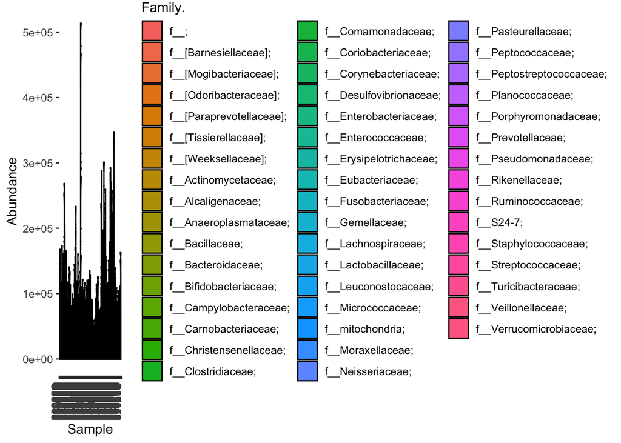

```r
#Plotting the phyloseq
plot_bar(physeq, fill = "Family.")
```

### Question 3.

Generate Alpha diversity plots and ordination plots. Examine any observed patterns by delivery mode, gender and disease status

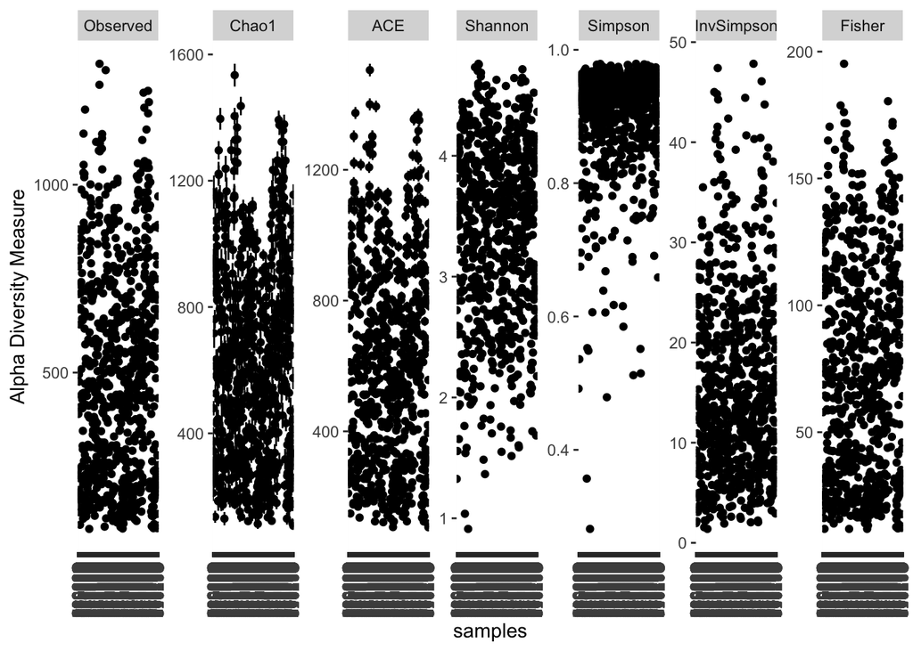

```r
plot_richness(physeq)  #Default plot produced by the plot_richness function
```

##### 3.1. To observe patterns across variables, we need to merge the sample data into the phyloseq object.

```r
library(tibble)
s_data <- column_to_rownames(data, var="Sample_ID")
s_data <- sample_data(s_data)
#s_data

mergedPhyseq = merge_phyloseq(physeq, s_data)
mergedPhyseq
```

```
## phyloseq-class experiment-level object
## otu_table()   OTU Table:         [ 2240 taxa and 777 samples ]
## sample_data() Sample Data:       [ 777 samples by 5 sample variables ]
## tax_table()   Taxonomy Table:    [ 2240 taxa by 7 taxonomic ranks ]
```

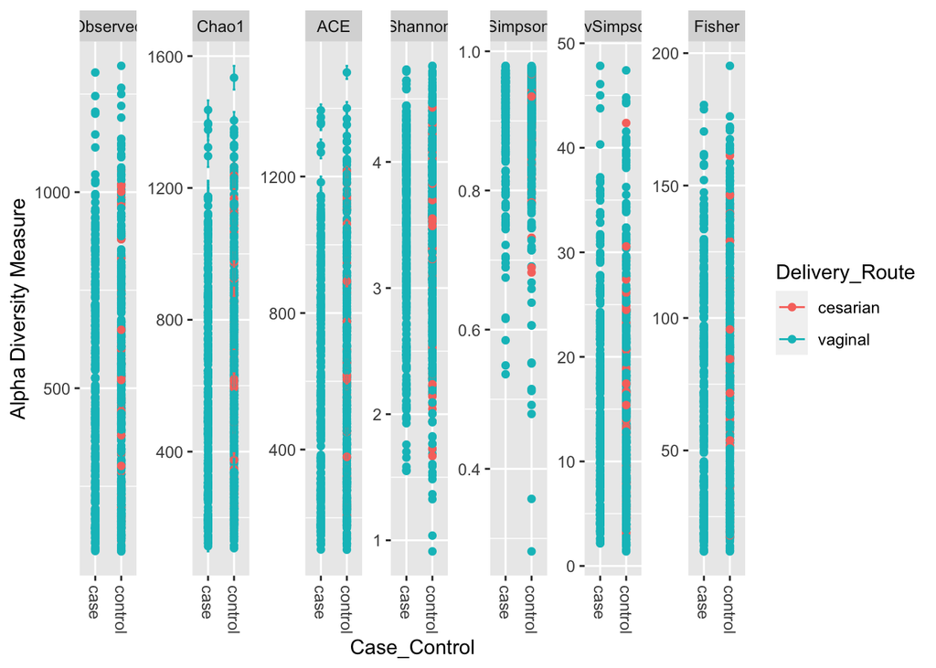

```r
plot_richness(mergedPhyseq, x ="Case_Control", color="Delivery_Route")
```

#### 3.3. Alpha diversity comparison between the Gender and Case Control

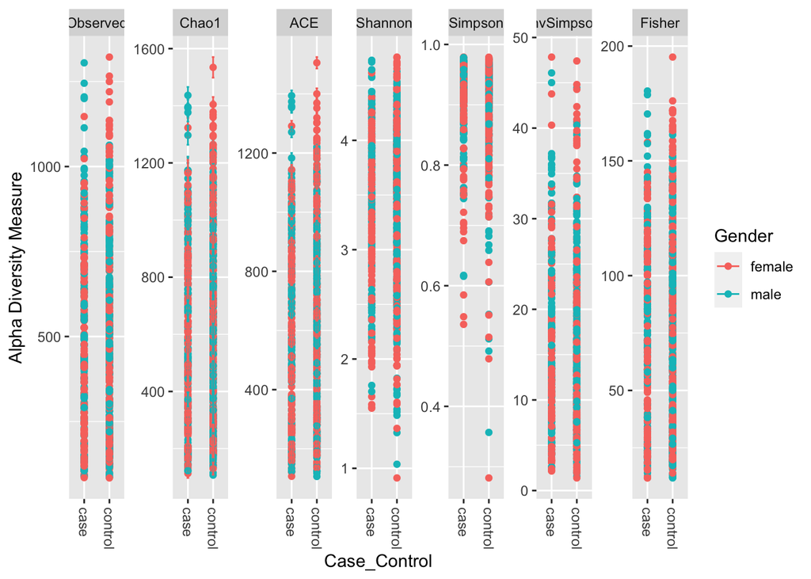

```r
plot_richness(mergedPhyseq, x ="Case_Control", color="Gender")
```

#### 3.4. Alpha diversity comparison between the Age and Case Control

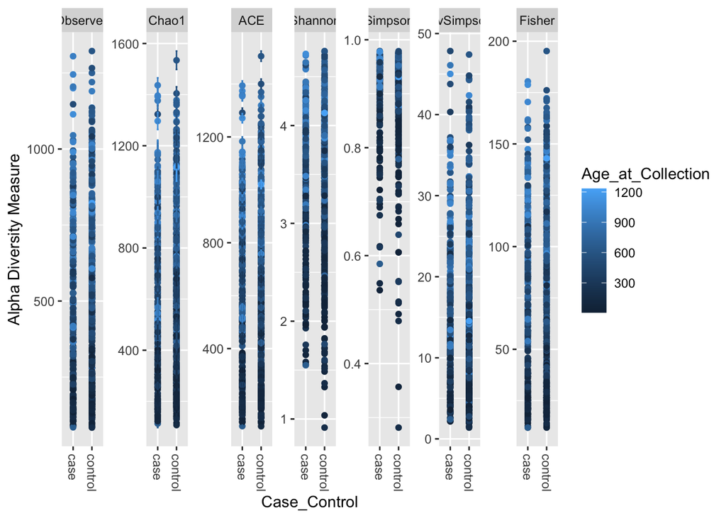

```r
plot_richness(mergedPhyseq, x ="Case_Control", color="Age_at_Collection")
```

### Question 4

Perform differential abundance using DESEq2

#### 4.1. DESeq2 conversion and call

The function *phyloseq_to_deseq2* converts your phyloseq-format microbiome data into a DESeqDataSet with dispersions estimated, using the experimental design formula. The DESeq function does the rest of the testing, in this case with default testing framework

```r
library(DESeq2)
head(sample_data(mergedPhyseq)$Case_Control, 20)  # Summary of the first 20 entries for the study design factor
```

```
##  [1] "control" "control" "control" "control" "control" "control" "control"
##  [8] "control" "control" "control" "control" "control" "control" "control"
## [15] "control" "control" "control" "case"    "case"    "control"
```

```r
deseqData = phyloseq_to_deseq2(mergedPhyseq, ~ Case_Control) # Converts the phyloseq-format microbiome data into a DESeqDataSet with dispersions estimated, using the experimental design formula
#deseqData = DESeq(diagdds, test="Wald", fitType = "parametric")

#The above function as noted on the phyloseq site returns an error. Issue is resolved here https://github.com/joey711/phyloseq/issues/387 and the function used in the next steps is got from the same link

gm_mean = function(x, na.rm=TRUE){
  exp(sum(log(x[x > 0]), na.rm=na.rm) / length(x))
}
geoMeans = apply(counts(deseqData), 1, gm_mean)
deseqData = estimateSizeFactors(deseqData, geoMeans = geoMeans)
deseqData = DESeq(deseqData, fitType = "local")
```

```
## -- replacing outliers and refitting for 1151 genes
## -- DESeq argument 'minReplicatesForReplace' = 7
## -- original counts are preserved in counts(dds)
```

#### 4.2. Investigate test results table

```r
library(DESeq2)
res = results(deseqData, cooksCutoff = FALSE)
alpha = 0.01
sigtab = res[which(res$padj < alpha), ]
sigtab = cbind(as(sigtab, "data.frame"), as(tax_table(mergedPhyseq)[rownames(sigtab), ], "matrix"))
head(sigtab)
```

|  | baseMean | log2FoldChange | lfcSE | stat | pvalue | padj | Domain. | Phylum. | Class. | Order. | Family. | Genus. | Species |
| --- | --- | --- | --- | --- | --- | --- | --- | --- | --- | --- | --- | --- | --- |
| 134726 | 5.650900 | 2.131322 | 0.5665873 | 3.761684 | 1.687732e-04 | 1.740775e-03 | k__Bacteria; | p__Firmicutes; | c__Bacilli; | o__Lactobacillales; | f__Lactobacillaceae; | g__Lactobacillus; | s__ |
| 193672 | 91.723631 | 1.574409 | 0.2337252 | 6.736154 | 1.626344e-11 | 1.174221e-09 | k__Bacteria; | p__Firmicutes; | c__Clostridia; | o__Clostridiales; | f__Clostridiaceae; | g__; | s__ |
| 4439360 | 1081.732052 | 1.293402 | 0.2627492 | 4.922573 | 8.541366e-07 | 1.932538e-05 | k__Bacteria; | p__Bacteroidetes; | c__Bacteroidia; | o__Bacteroidales; | f__Bacteroidaceae; | g__Bacteroides; | s__ |
| 306299 | 7.927932 | 1.012594 | 0.2723463 | 3.718038 | 2.007759e-04 | 2.013336e-03 | k__Bacteria; | p__Firmicutes; | c__Clostridia; | o__Clostridiales; | f__Lachnospiraceae; | g__; | s__ |
| 1142029 | 25.917987 | -1.281228 | 0.2383396 | -5.375638 | 7.631189e-08 | 2.648903e-06 | k__Bacteria; | p__Actinobacteria; | c__Actinobacteria; | o__Bifidobacteriales; | f__Bifidobacteriaceae; | g__Bifidobacterium; | s__ |
| 4372612 | 14.952956 | 1.153458 | 0.2793272 | 4.129415 | 3.636874e-05 | 4.935757e-04 | k__Bacteria; | p__Bacteroidetes; | c__Bacteroidia; | o__Bacteroidales; | f__Bacteroidaceae; | g__Bacteroides; | s__ |

```r
dim(sigtab)
```

```
## [1] 281  13
```

#### 4.3. A plot of the summary of the results

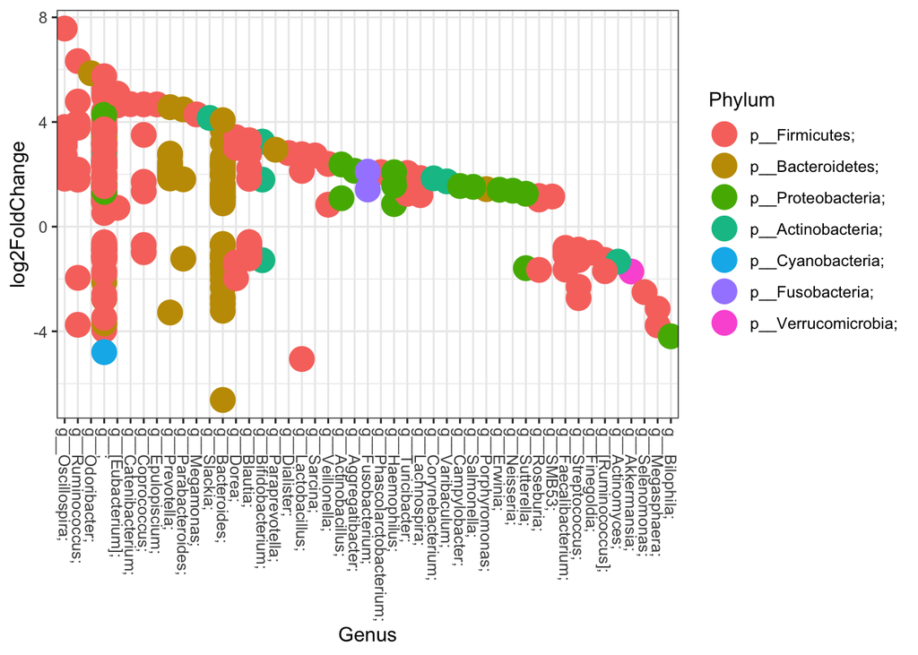

```r
library("ggplot2")
theme_set(theme_bw())
scale_fill_discrete <- function(palname = "Set1", ...) {
  scale_fill_brewer(palette = palname, ...)
}
# Phylum order
x = tapply(sigtab$log2FoldChange, sigtab$Phylum, function(x) max(x))
x = sort(x, TRUE)
sigtab$Phylum = factor(as.character(sigtab$Phylum), levels=names(x))
# Genus order
x = tapply(sigtab$log2FoldChange, sigtab$Genus, function(x) max(x))
x = sort(x, TRUE)
sigtab$Genus = factor(as.character(sigtab$Genus), levels=names(x))
ggplot(sigtab, aes(x=Genus, y=log2FoldChange, color=Phylum)) + geom_point(size=6) +
  theme(axis.text.x = element_text(angle = -90, hjust = 0, vjust=0.5))
```